# HEIDI: Marian

**Institution Profile**

**Classification:** Special Focus: Medical Schools and Centers

**Size:** Medium

**Award Level Focus:** Undergraduate/Graduate-Doctorate

**UG Program Mix:** Special Focus: Medical Schools and Centers

**Grad Program Mix:** Special Focus: Medical Schools and Centers

**Research Activity:** Research Colleges and Universities

**Student Access & Earnings:** Not Classified in SAEC

**Location**

[interactive chart not shown]

#### Higher Education Institutional Data Interface (HEIDI)

HEIDI is a dashboard tool created by the Casagrande Institute to report data for institutions of higher education.

#### Casagrande Institute

The [Casagrande Institute](https://www.viterbo.edu/casagrande-institute/) helps institutions develop effective compensation practices for executives, faculty, and staff.

[figure not shown]

**David J. Bauer, Ph.D.**  
Director, Casagrande Institute  
djbauer@viterbo.edu  
608-796-3617  
[LinkedIn](https://www.linkedin.com/in/davidjbauer/)

**Group Overview**

- **A: Original Peer**: The group of comparison institutions submitted to IPEDS by Marian in 2024-25.
- **B: Original Peer Subset**: A subset of the Original Peer comparison group by Marian University (IN), previously used to inform executive compensation decisions.
- **C: Recommended**: Group of institutions recommended for Marian University (IN) compensation benchmarking. Private NFP, Expenses $100M - $300M, Total FTE 3,000 - 8,000, and the following Carnegie classifications: Professions-focused Undergraduate/Graduate-Doctorate Large, Professions-focused Undergraduate/Graduate-Doctorate Medium, Professions-focused Undergraduate/Graduate-Doctorate Small, Special Focus: Medical Schools and Centers, Special Focus: Nursing, Special Focus: Other Health Professions. Based on IPEDS data from 2024-25.
- **D: NFP Osteo / Medical**: Group of Private NFP institutions with Expenses up to $500M that satisfy one or more of the following criteria: 1. membership in the American Association of Colleges of Osteopathic Medicine (AACOM) institutions in 2026, 2. membership in the Commission on Osteopathic College Accreditation (COCA) institutions in 2026, or 3. a 2025 Carnegie classification of “Special Focus: Medical Schools and Centers”. Excludes institutions in Puerto Rico.

**Group Membership**

| Institution | A: Original Peer | B: Original Peer Subset | C: Recommended | D: NFP Osteo / Medical |
| --- | --- | --- | --- | --- |
| A T Still University of Health Sciences |  |  | ✓ | ✓ |
| Abilene Christian University |  |  | ✓ |  |
| Adelphi University |  |  | ✓ |  |
| Alabama College of Osteopathic Medicine |  |  |  | ✓ |
| Arkansas Colleges of Health Education |  |  |  | ✓ |
| Ashland University |  |  | ✓ |  |
| Aurora University |  |  | ✓ |  |
| Azusa Pacific University |  |  | ✓ |  |
| Baptist Health Sciences University |  |  |  | ✓ |
| Barry University |  |  | ✓ |  |

[output cut: 82 more lines]

**A: Original Peer**

[interactive table not shown]

**B: Original Peer Subset**

[interactive table not shown]

**C: Recommended**

[interactive table not shown]

**D: NFP Osteo / Medical**

[interactive table not shown]

**A: Original Peer**

**Financial and Student Positioning of Marian Within the A: ORIGINAL PEER Group**

| Metric | **A: ORIGINAL PEER Group** n | **A: ORIGINAL PEER Group** Min | **A: ORIGINAL PEER Group** p25 | **A: ORIGINAL PEER Group** Median | **A: ORIGINAL PEER Group** p75 | **A: ORIGINAL PEER Group** Max | **Spread** Spread | **Marian** Marian | **Marian** Percentile | **Marian** % of Median |
| --- | --- | --- | --- | --- | --- | --- | --- | --- | --- | --- |
| Revenue | 15 | 85.3M | 161.4M | 264.7M | 594.6M | 741.4M |  | 173.2M | 30 | 65% |
| Expenses | 15 | 75.7M | 148.1M | 219.6M | 491.0M | 657.9M |  | 141.5M | 30 | 64% |
| Margin | 15 | 4.5M | 22.1M | 52.3M | 86.6M | 126.6M |  | 31.7M | 50 | 61% |
| Endowment | 15 | 55.1M | 160.0M | 297.2M | 824.0M | 1.9B |  | 126.9M | 23 | 43% |
| Avg Net Price | 15 | 21.4k | 23.6k | 27.7k | 33.2k | 38.4k |  | 22.8k | 17 | 82% |
| Avg Net Price + 0.04 * Endowment / UG FTE | 15 | 23.0k | 26.4k | 35.8k | 37.2k | 40.9k |  | 24.6k | 23 | 69% |
| 12-Month Unduplicated Headcount | 15 | 2,888 | 5,870 | 6,731 | 11,184 | 24,433 |  | 4,696 | 23 | 70% |
| Undergrad FTE | 15 | 1,424 | 2,848 | 4,752 | 7,038 | 14,475 |  | 2,872 | 30 | 60% |
| Grad FTE | 15 | 326 | 764 | 960 | 1,972 | 4,534 |  | 518 | 17 | 54% |
| Doc Prof Prac FTE | 14 | 151 | 306 | 533 | 1,309 | 2,995 |  | 679 | 61 | 127% |
| Total FTE | 15 | 2,467 | 4,602 | 6,203 | 9,916 | 19,740 |  | 4,069 | 23 | 66% |
| Student-to-Faculty Ratio | 15 | 9.0 | 11.0 | 12.0 | 14.0 | 17.0 |  | 13.0 | 73 | 108% |
| Undergrad Pell % | 15 | 12 | 16 | 27 | 32 | 45 |  | 29 | 57 | 107% |

Data from IPEDS for the 2024-25 academic year. Group values exclude data from Marian.

**B: Original Peer Subset**

**Financial and Student Positioning of Marian Within the B: ORIGINAL PEER SUBSET Group**

[output not shown]

Data from IPEDS for the 2024-25 academic year. Group values exclude data from Marian.

**C: Recommended**

**Financial and Student Positioning of Marian Within the C: RECOMMENDED Group**

| Metric | **C: RECOMMENDED Group** n | **C: RECOMMENDED Group** Min | **C: RECOMMENDED Group** p25 | **C: RECOMMENDED Group** Median | **C: RECOMMENDED Group** p75 | **C: RECOMMENDED Group** Max | **Spread** Spread | **Marian** Marian | **Marian** Percentile | **Marian** % of Median |
| --- | --- | --- | --- | --- | --- | --- | --- | --- | --- | --- |
| Revenue | 54 | 100.9M | 125.7M | 174.4M | 233.4M | 403.1M |  | 173.2M | 51 | 99% |
| Expenses | 54 | 101.3M | 124.1M | 154.9M | 188.8M | 293.8M |  | 141.5M | 44 | 91% |
| Margin | 54 | −17.7M | 3.8M | 15.7M | 30.0M | 145.9M |  | 31.7M | 81 | 202% |
| Endowment | 54 | 3.2M | 75.2M | 137.3M | 251.3M | 821.9M |  | 126.9M | 45 | 92% |
| Avg Net Price | 49 | 13.2k | 22.8k | 27.2k | 31.9k | 50.0k |  | 22.8k | 26 | 84% |
| Avg Net Price + 0.04 * Endowment / UG FTE | 49 | 13.9k | 24.4k | 28.9k | 34.9k | 53.1k |  | 24.6k | 28 | 85% |
| 12-Month Unduplicated Headcount | 54 | 3,191 | 5,001 | 5,770 | 6,928 | 12,807 |  | 4,696 | 21 | 81% |
| Undergrad FTE | 50 | 10 | 2,501 | 3,223 | 4,017 | 5,429 |  | 2,872 | 41 | 89% |
| Grad FTE | 54 | 412 | 745 | 965 | 1,379 | 2,805 |  | 518 | 8 | 54% |
| Doc Prof Prac FTE | 47 | 32 | 202 | 420 | 1,206 | 3,941 |  | 679 | 69 | 162% |
| Total FTE | 54 | 3,191 | 3,933 | 4,652 | 6,099 | 7,866 |  | 4,069 | 31 | 87% |
| Student-to-Faculty Ratio | 50 | 2.0 | 11.0 | 12.0 | 14.0 | 21.0 |  | 13.0 | 68 | 108% |
| Undergrad Pell % | 50 | 0 | 22 | 29 | 35 | 70 |  | 29 | 51 | 100% |

Data from IPEDS for the 2024-25 academic year. Group values exclude data from Marian.

**D: NFP Osteo / Medical**

**Financial and Student Positioning of Marian Within the D: NFP OSTEO / MEDICAL Group**

| Metric | **D: NFP OSTEO / MEDICAL Group** n | **D: NFP OSTEO / MEDICAL Group** Min | **D: NFP OSTEO / MEDICAL Group** p25 | **D: NFP OSTEO / MEDICAL Group** Median | **D: NFP OSTEO / MEDICAL Group** p75 | **D: NFP OSTEO / MEDICAL Group** Max | **Spread** Spread | **Marian** Marian | **Marian** Percentile | **Marian** % of Median |
| --- | --- | --- | --- | --- | --- | --- | --- | --- | --- | --- |
| Revenue | 38 | 16.2M | 76.7M | 142.6M | 245.3M | 438.9M |  | 173.2M | 59 | 121% |
| Expenses | 38 | 26.0M | 82.8M | 122.4M | 188.8M | 426.2M |  | 141.5M | 57 | 116% |
| Margin | 38 | −98.5M | 6.5M | 15.7M | 32.1M | 145.9M |  | 31.7M | 75 | 201% |
| Endowment | 36 | 217.7k | 29.0M | 75.2M | 173.4M | 1.0B |  | 126.9M | 65 | 169% |
| Avg Net Price | 14 | 11.3k | 16.8k | 23.4k | 28.3k | 40.0k |  | 22.8k | 46 | 97% |
| Avg Net Price + 0.04 * Endowment / UG FTE | 14 | 14.3k | 21.8k | 26.3k | 39.4k | 101.8k |  | 24.6k | 39 | 93% |
| 12-Month Unduplicated Headcount | 38 | 227 | 1,108 | 2,130 | 4,242 | 14,626 |  | 4,696 | 78 | 220% |
| Undergrad FTE | 19 | 10 | 382 | 1,202 | 2,975 | 5,602 |  | 2,872 | 76 | 239% |
| Grad FTE | 33 | 8 | 339 | 725 | 1,047 | 3,808 |  | 518 | 44 | 71% |
| Doc Prof Prac FTE | 38 | 19 | 584 | 1,020 | 1,835 | 3,941 |  | 679 | 30 | 67% |
| Total FTE | 38 | 227 | 1,093 | 2,151 | 4,056 | 10,757 |  | 4,069 | 75 | 189% |
| Student-to-Faculty Ratio | 20 | 2.0 | 5.0 | 10.0 | 12.0 | 17.0 |  | 13.0 | 80 | 130% |
| Undergrad Pell % | 20 | 0 | 19 | 32 | 40 | 55 |  | 29 | 42 | 89% |

Data from IPEDS for the 2024-25 academic year. Group values exclude data from Marian.

**A: Original Peer**

**Revenue**

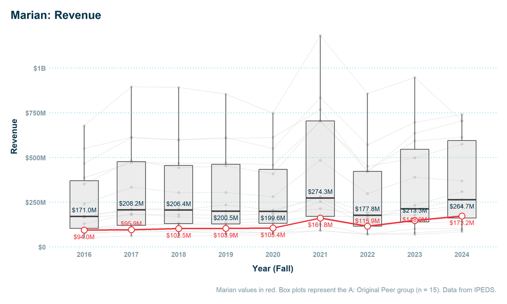

**Expenses**

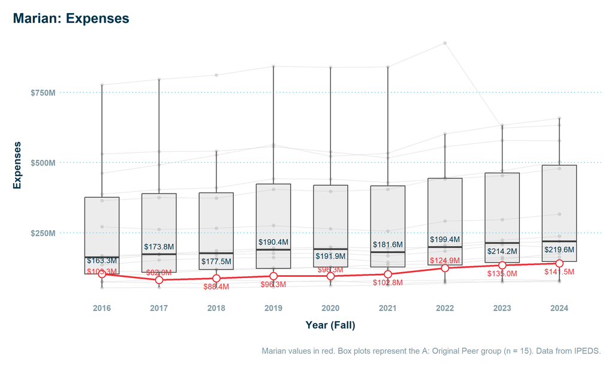

**Margin**

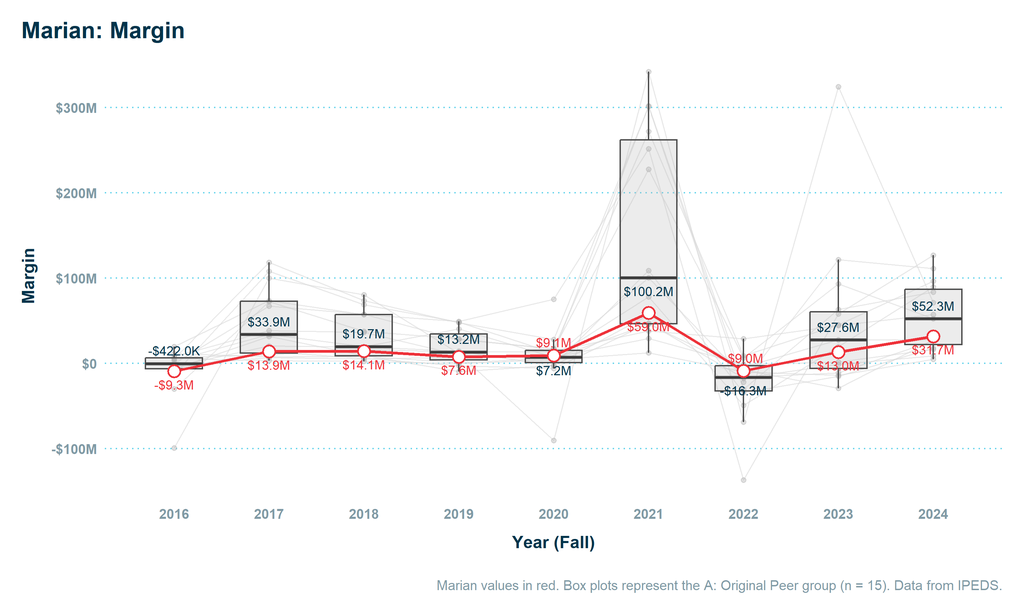

**Endowment**

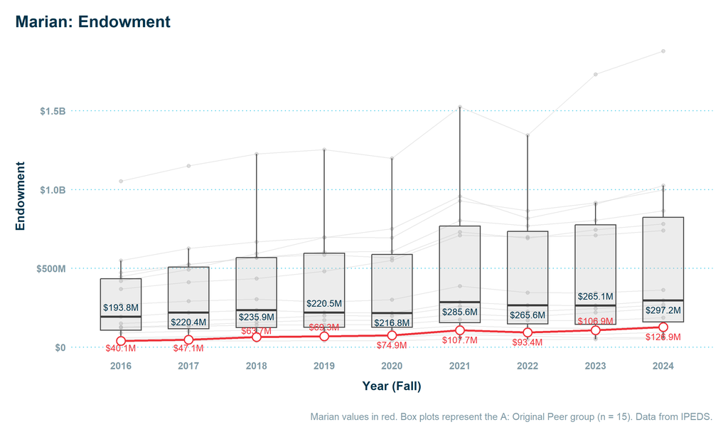

**Avg Net Price**

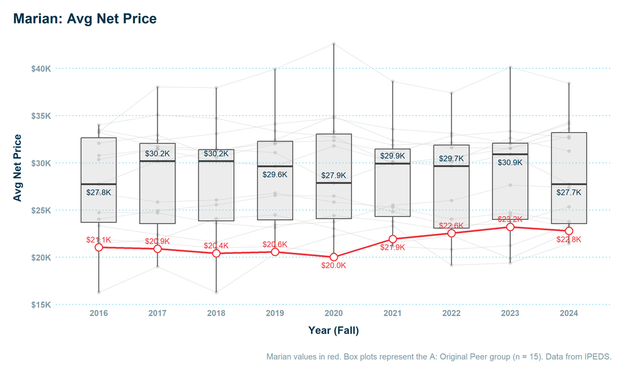

**Avg Net Price + 0.04 * Endowment / UG FTE**

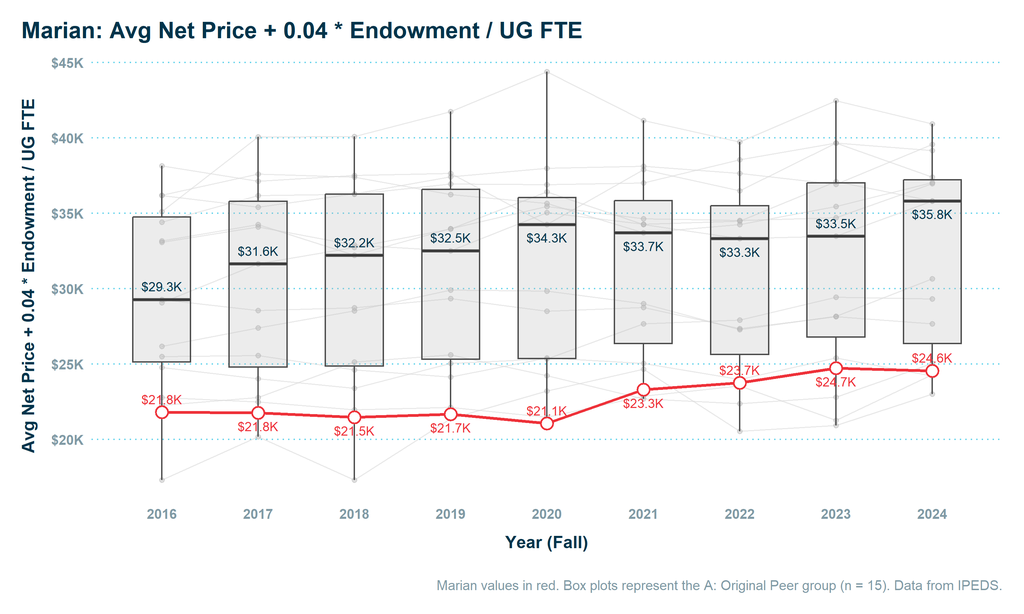

**12-Month Unduplicated Headcount**

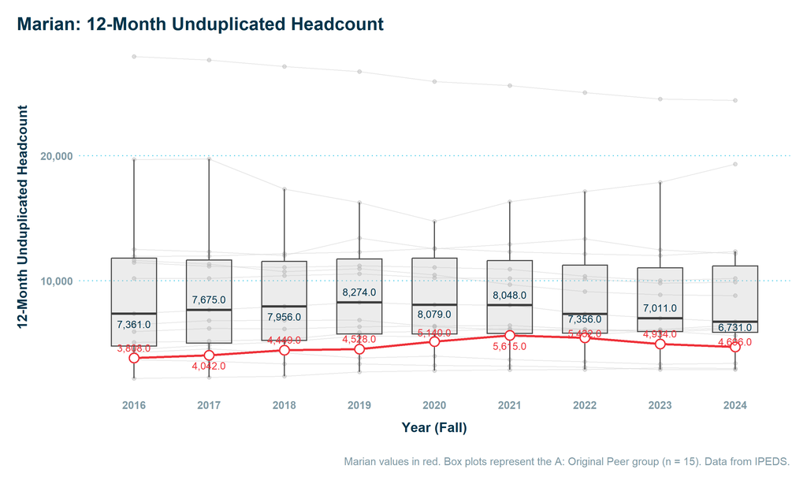

**Undergrad FTE**

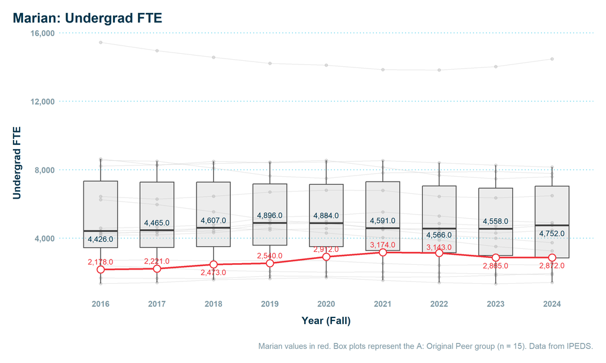

**Grad FTE**

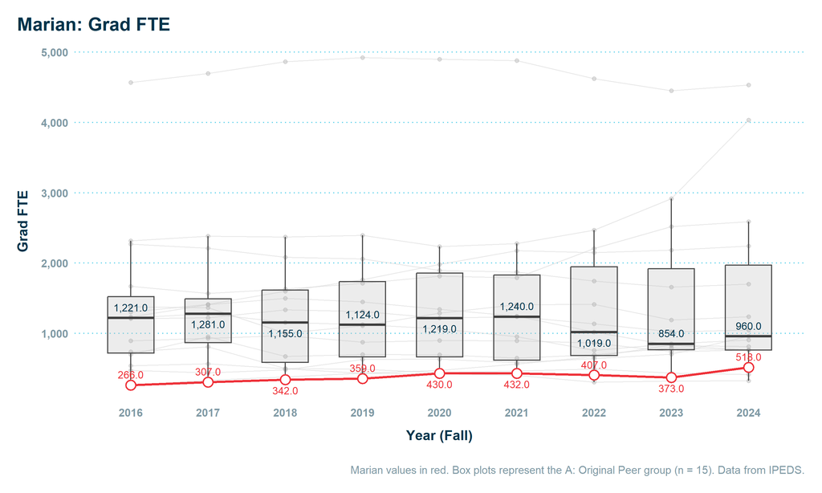

**Doc Prof Prac FTE**

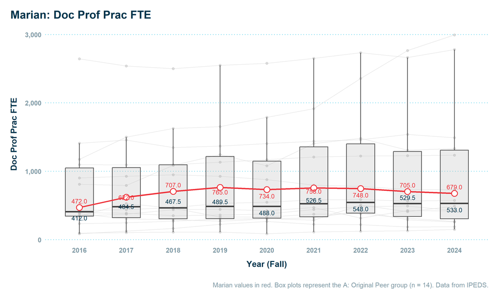

**Total FTE**

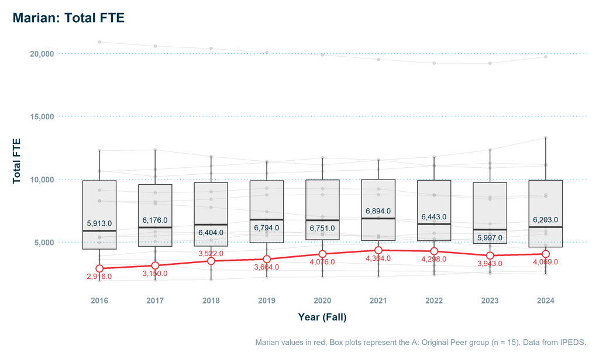

**Student-to-Faculty Ratio**

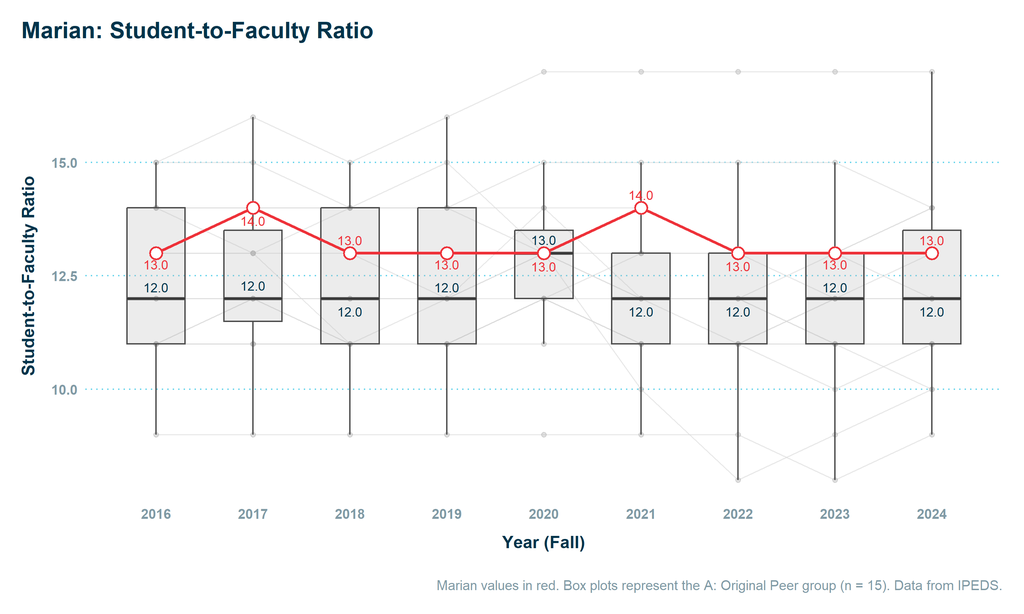

**Undergrad Pell %**

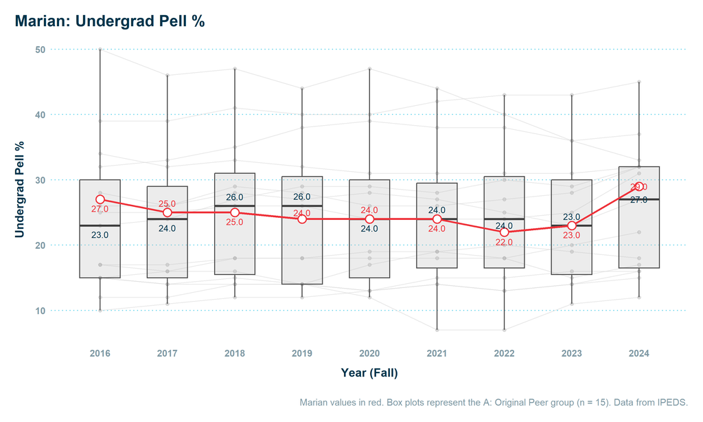

**B: Original Peer Subset**

**Revenue**

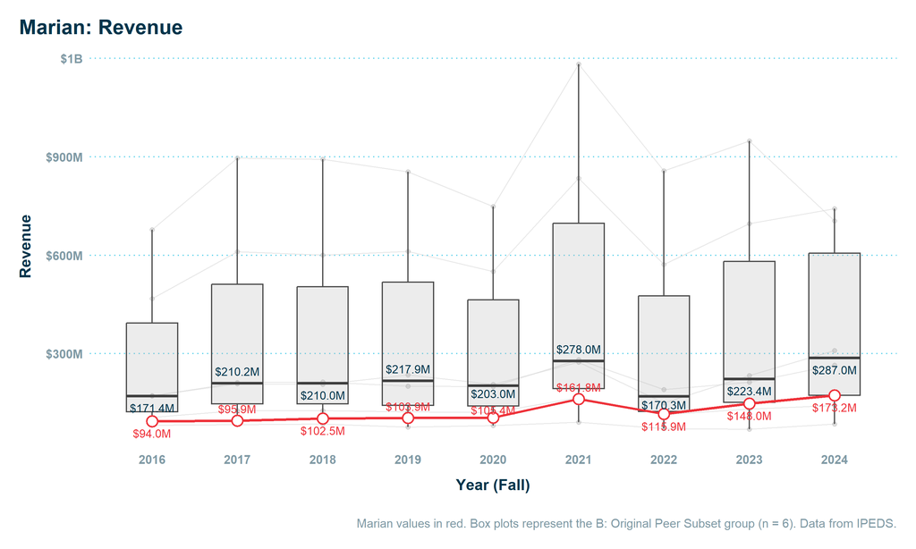

**Expenses**

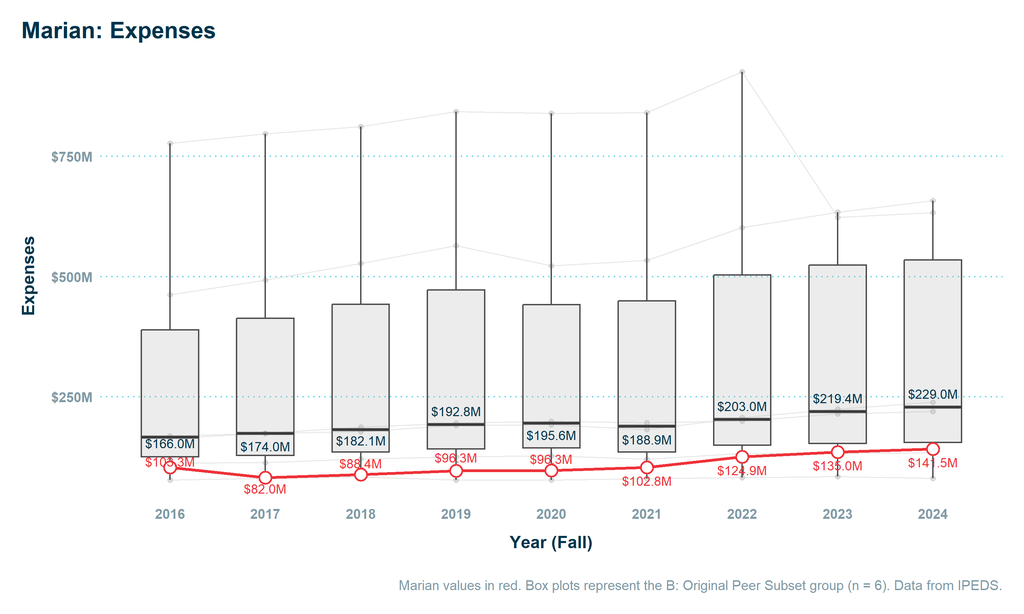

**Margin**

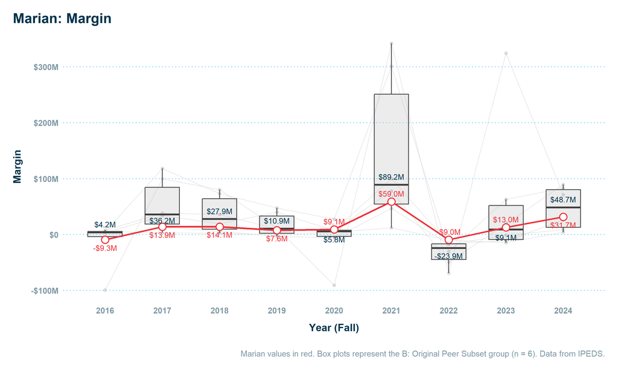

**Endowment**

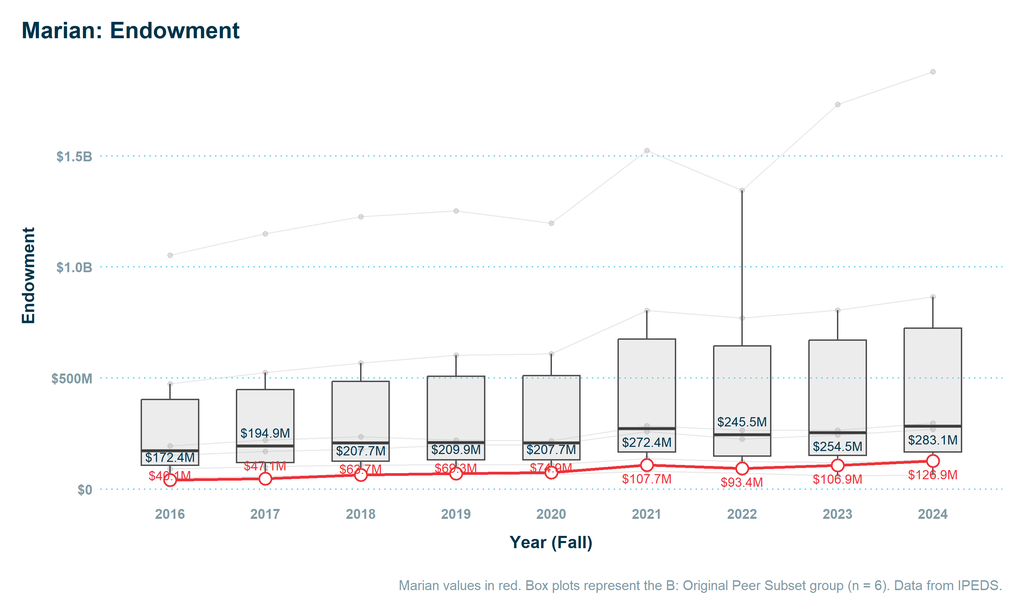

**Avg Net Price**

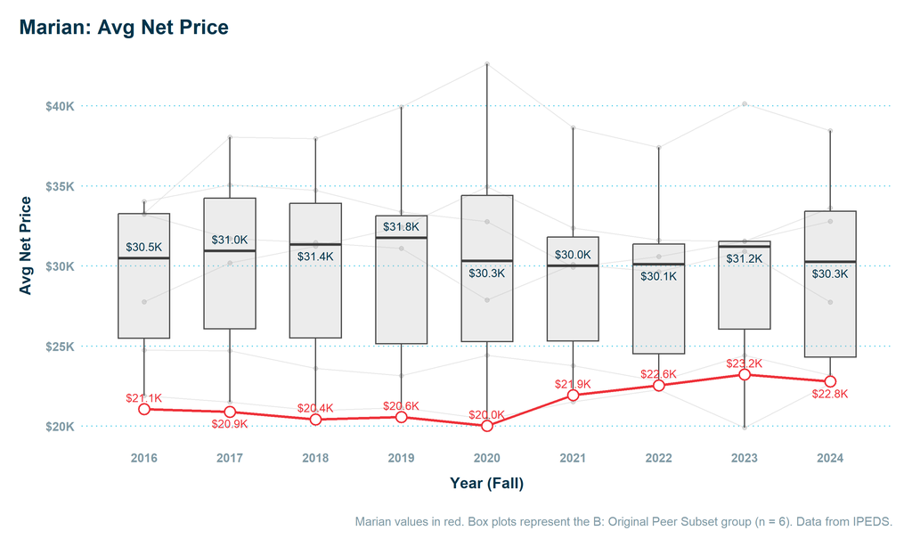

**Avg Net Price + 0.04 * Endowment / UG FTE**

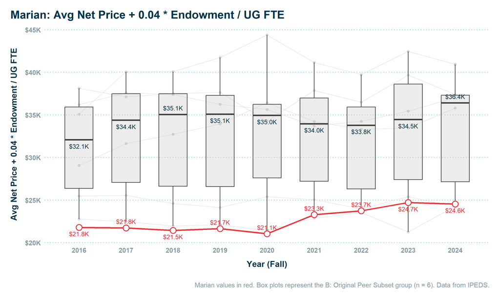

**12-Month Unduplicated Headcount**

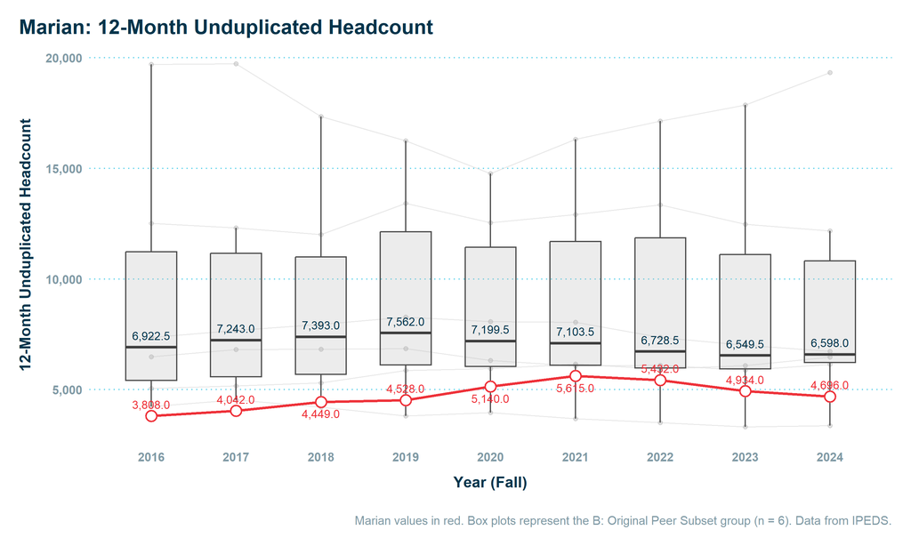

**Undergrad FTE**

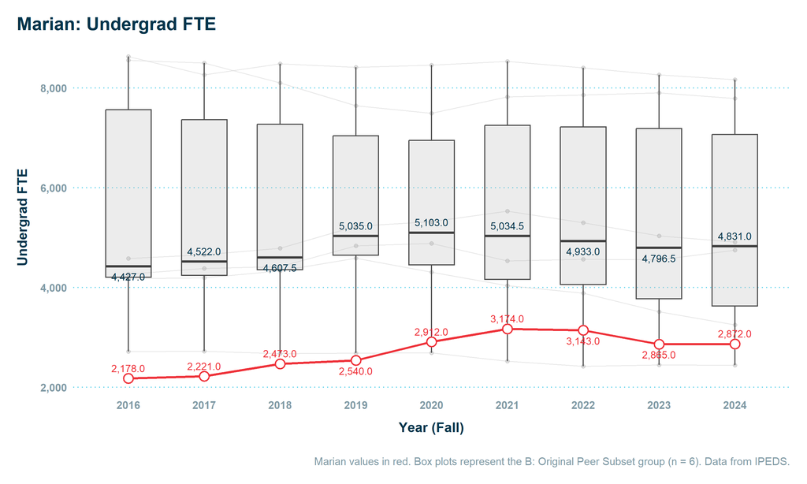

**Grad FTE**

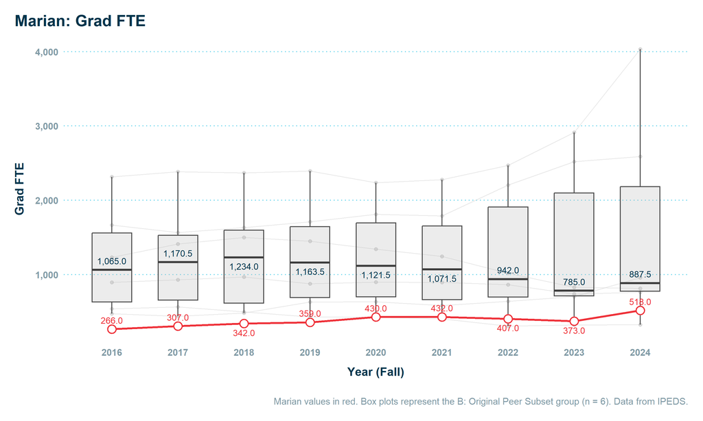

**Doc Prof Prac FTE**

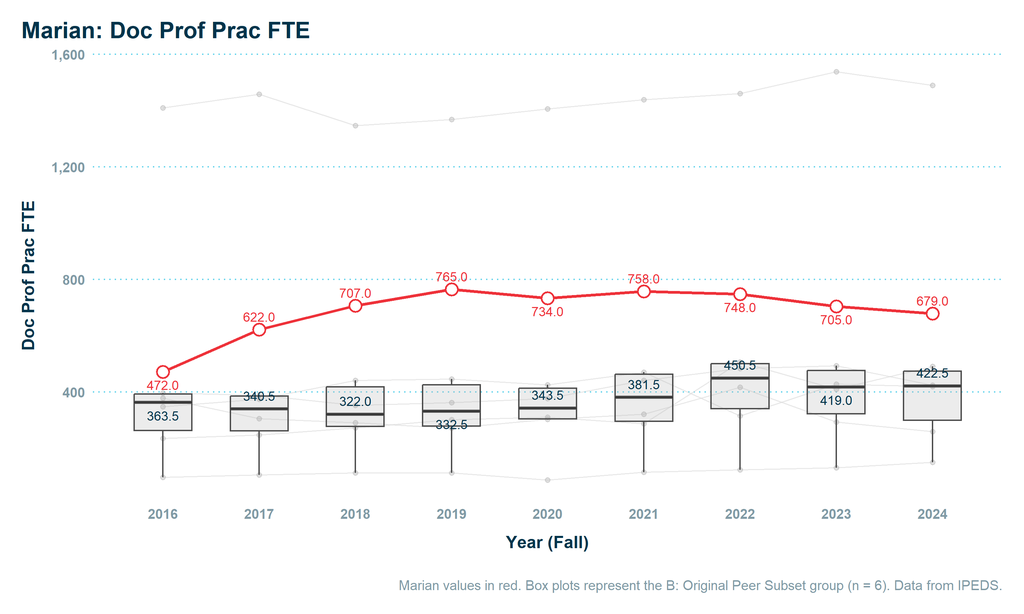

**Total FTE**

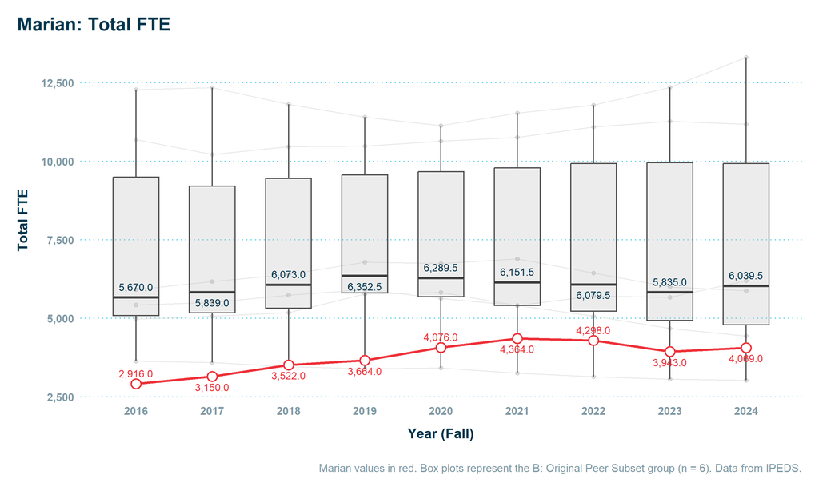

**Student-to-Faculty Ratio**

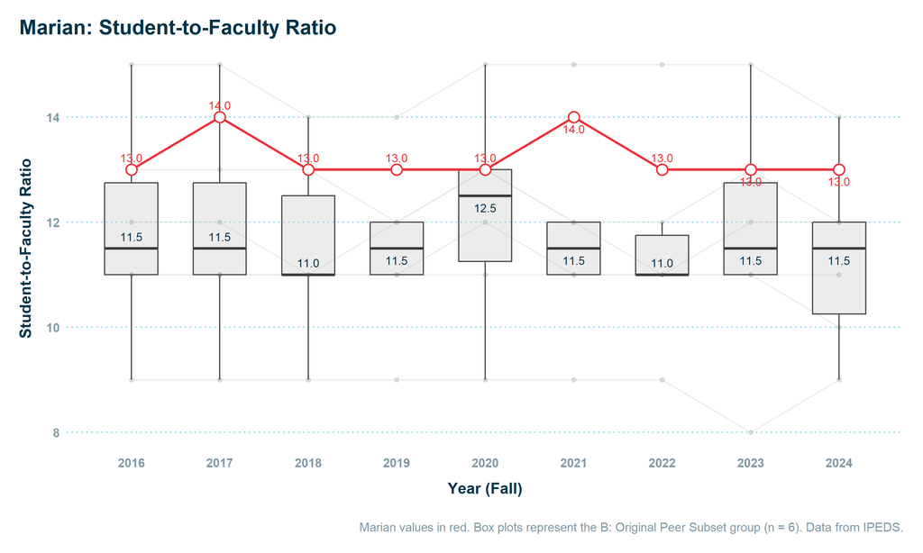

**Undergrad Pell %**

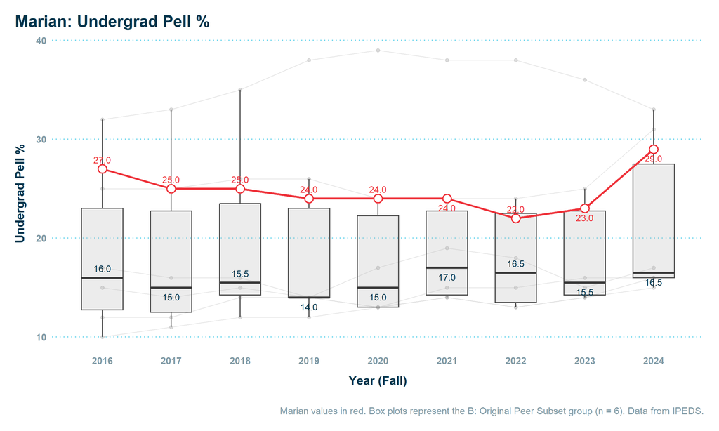

**C: Recommended**

**Revenue**

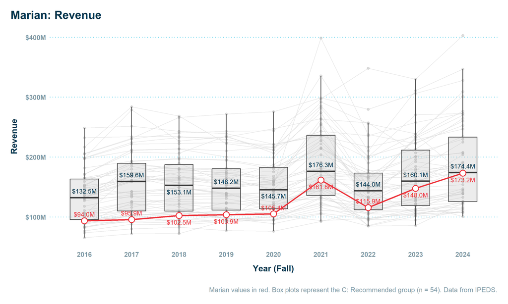

**Expenses**

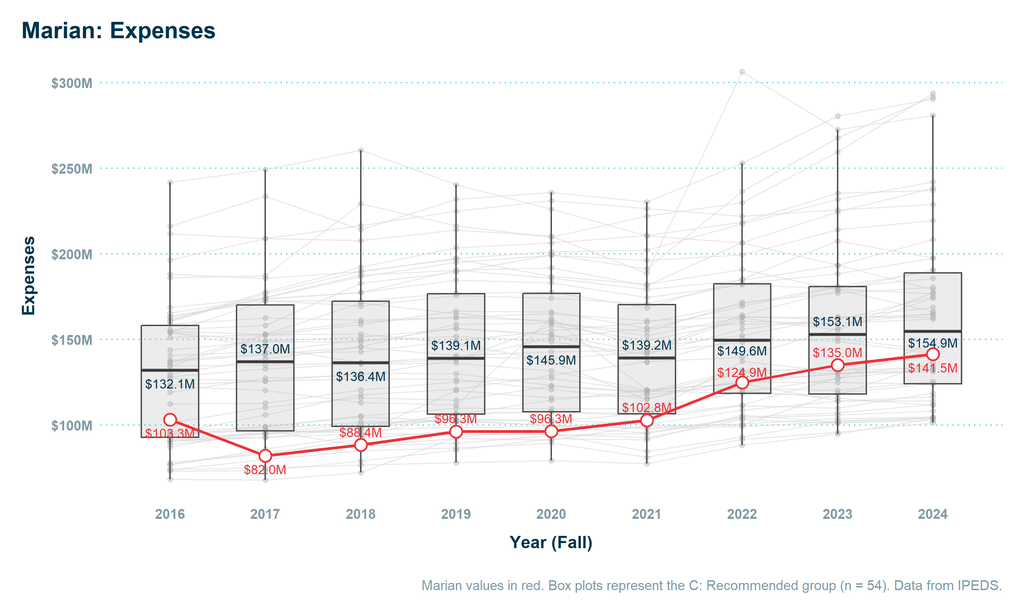

**Margin**

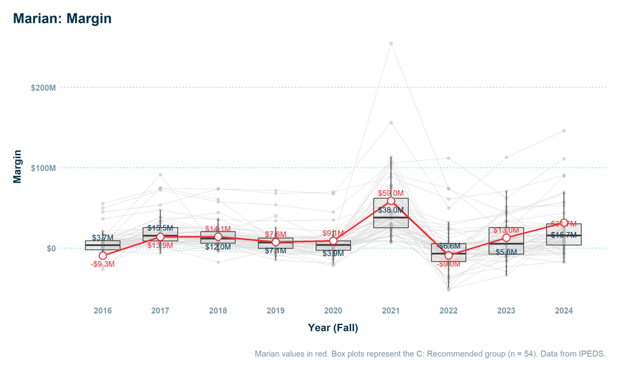

**Endowment**

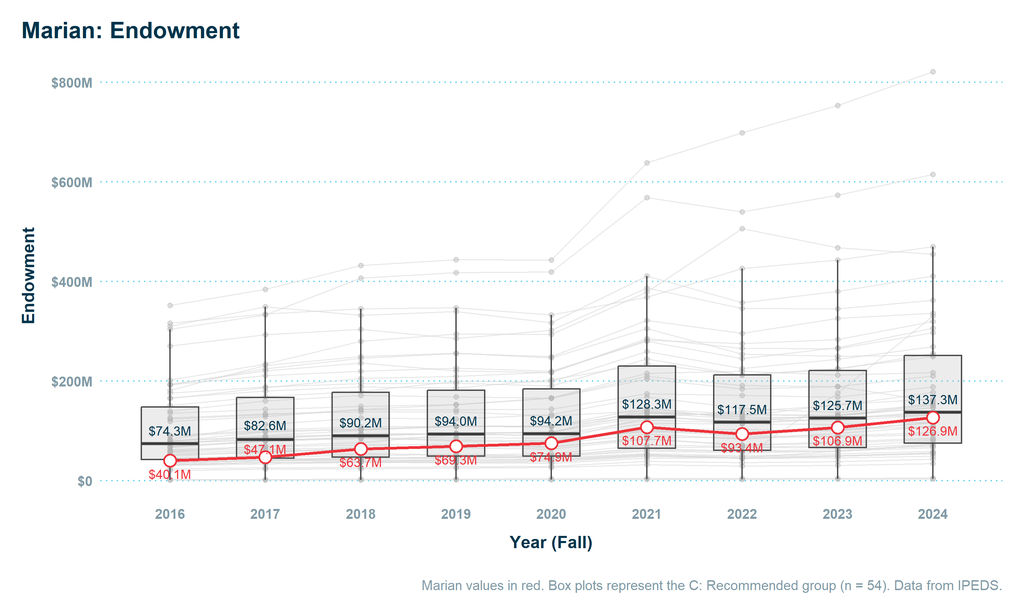

**Avg Net Price**